# USL Part 2: PCA

Evrim Bilgen

12/17/2021

# **PCA ANALYSIS**

## Our packages

```r
library(readr)
library(dplyr)
```

```r
library(ggplot2)
library(corrplot)
library(gridExtra)
library(pROC)
library(MASS)
library(caTools)
library(caret)
library(caretEnsemble)
library(doMC)
library(DataExplorer)
```

## Our Data & Cleaning & Manipulating (EDA)

```r
cardio = read.csv("/Users/ewrimmm/Desktop/R exercises/USL_21/cardio.csv")
```

```r
attach(cardio)

glimpse(cardio)
```

```
## Rows: 303
## Columns: 14
## $ sex      <int> 1, 1, 0, 1, 0, 1, 0, 1, 1, 1, 1, 0, 1, 1, 0, 0, 0, 0, 1, 0, 1…
## $ target   <int> 1, 1, 1, 1, 1, 1, 1, 1, 1, 1, 1, 1, 1, 1, 1, 1, 1, 1, 1, 1, 1…
## $ slope    <int> 0, 0, 2, 2, 2, 1, 1, 2, 2, 2, 2, 2, 2, 1, 2, 1, 2, 0, 2, 2, 1…
## $ exang    <int> 0, 0, 0, 0, 1, 0, 0, 0, 0, 0, 0, 0, 0, 1, 0, 0, 0, 0, 0, 0, 0…
## $ restecg  <int> 0, 1, 0, 1, 1, 1, 0, 1, 1, 1, 1, 1, 1, 0, 0, 1, 1, 1, 1, 1, 1…
## $ fbs      <int> 1, 0, 0, 0, 0, 0, 0, 0, 1, 0, 0, 0, 0, 0, 1, 0, 0, 0, 0, 0, 0…
## $ cp       <int> 3, 2, 1, 1, 0, 0, 1, 1, 2, 2, 0, 2, 1, 3, 3, 2, 2, 3, 0, 3, 0…
## $ ca       <int> 0, 0, 0, 0, 0, 0, 0, 0, 0, 0, 0, 0, 0, 0, 0, 0, 0, 0, 0, 2, 0…
## $ thal     <int> 1, 2, 2, 2, 2, 1, 2, 3, 3, 2, 2, 2, 2, 2, 2, 2, 2, 2, 2, 2, 3…
## $ age      <int> 63, 37, 41, 56, 57, 57, 56, 44, 52, 57, 54, 48, 49, 64, 58, 5…
## $ trestbps <int> 145, 130, 130, 120, 120, 140, 140, 120, 172, 150, 140, 130, 1…
## $ chol     <int> 233, 250, 204, 236, 354, 192, 294, 263, 199, 168, 239, 275, 2…
## $ thalach  <int> 150, 187, 172, 178, 163, 148, 153, 173, 162, 174, 160, 139, 1…
## $ oldpeak  <dbl> 2.3, 3.5, 1.4, 0.8, 0.6, 0.4, 1.3, 0.0, 0.5, 1.6, 1.2, 0.2, 0…
```

Now, looking at out data’s structure

```r
str(cardio)
```

```
## 'data.frame':    303 obs. of  14 variables:
##  $ sex     : int  1 1 0 1 0 1 0 1 1 1 ...
##  $ target  : int  1 1 1 1 1 1 1 1 1 1 ...
##  $ slope   : int  0 0 2 2 2 1 1 2 2 2 ...
##  $ exang   : int  0 0 0 0 1 0 0 0 0 0 ...
##  $ restecg : int  0 1 0 1 1 1 0 1 1 1 ...
##  $ fbs     : int  1 0 0 0 0 0 0 0 1 0 ...
##  $ cp      : int  3 2 1 1 0 0 1 1 2 2 ...
##  $ ca      : int  0 0 0 0 0 0 0 0 0 0 ...
##  $ thal    : int  1 2 2 2 2 1 2 3 3 2 ...
##  $ age     : int  63 37 41 56 57 57 56 44 52 57 ...
##  $ trestbps: int  145 130 130 120 120 140 140 120 172 150 ...
##  $ chol    : int  233 250 204 236 354 192 294 263 199 168 ...
##  $ thalach : int  150 187 172 178 163 148 153 173 162 174 ...
##  $ oldpeak : num  2.3 3.5 1.4 0.8 0.6 0.4 1.3 0 0.5 1.6 ...
```

Checking the missing values

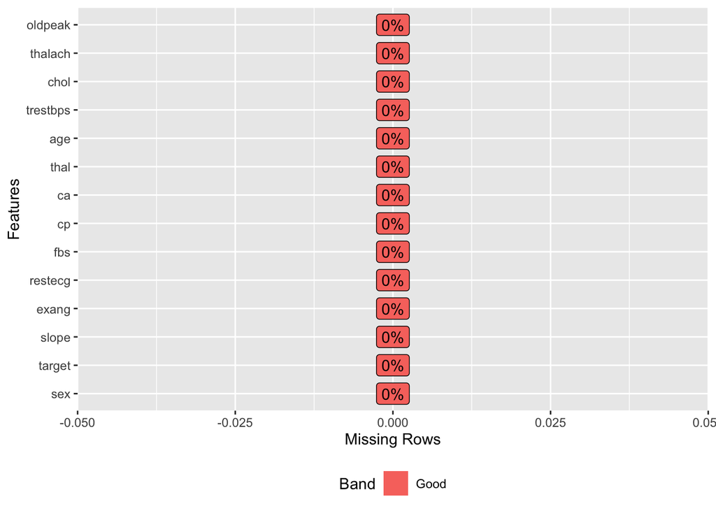

```r
plot_missing(cardio)
```

```r
cat("There are", sum(is.na(cardio)), "N/A values.")
```

```
## There are 0 N/A values.
```

There aren’t NA values.

Now, it’s time to change the sex and target columns for easy interpretation

```r
cardio$sex <- factor(cardio$sex, levels = c(0,1), labels = c("Female","Male"))
```

```r
cardio_2 <-cardio

cardio_2$target <- factor(cardio_2$target, levels = c(0,1), labels = c("No","Yes"))
```

In a nutshell, our data:

```r
summary(cardio)
```

```
##      sex          target           slope           exang
##  Female: 96   Min.   :0.0000   Min.   :0.000   Min.   :0.0000
##  Male  :207   1st Qu.:0.0000   1st Qu.:1.000   1st Qu.:0.0000
##               Median :1.0000   Median :1.000   Median :0.0000
##               Mean   :0.5446   Mean   :1.399   Mean   :0.3267
##               3rd Qu.:1.0000   3rd Qu.:2.000   3rd Qu.:1.0000
##               Max.   :1.0000   Max.   :2.000   Max.   :1.0000
##     restecg            fbs               cp              ca
##  Min.   :0.0000   Min.   :0.0000   Min.   :0.000   Min.   :0.0000
##  1st Qu.:0.0000   1st Qu.:0.0000   1st Qu.:0.000   1st Qu.:0.0000
##  Median :1.0000   Median :0.0000   Median :1.000   Median :0.0000
##  Mean   :0.5281   Mean   :0.1485   Mean   :0.967   Mean   :0.7294
##  3rd Qu.:1.0000   3rd Qu.:0.0000   3rd Qu.:2.000   3rd Qu.:1.0000
##  Max.   :2.0000   Max.   :1.0000   Max.   :3.000   Max.   :4.0000
##       thal            age           trestbps          chol
##  Min.   :0.000   Min.   :29.00   Min.   : 94.0   Min.   :126.0
##  1st Qu.:2.000   1st Qu.:47.50   1st Qu.:120.0   1st Qu.:211.0
##  Median :2.000   Median :55.00   Median :130.0   Median :240.0
##  Mean   :2.314   Mean   :54.37   Mean   :131.6   Mean   :246.3
##  3rd Qu.:3.000   3rd Qu.:61.00   3rd Qu.:140.0   3rd Qu.:274.5
##  Max.   :3.000   Max.   :77.00   Max.   :200.0   Max.   :564.0
##     thalach         oldpeak
##  Min.   : 71.0   Min.   :0.00
##  1st Qu.:133.5   1st Qu.:0.00
##  Median :153.0   Median :0.80
##  Mean   :149.6   Mean   :1.04
##  3rd Qu.:166.0   3rd Qu.:1.60
##  Max.   :202.0   Max.   :6.20
```

Target variable indicates that our candidate is a target for disease or not. So lets look at this variable

```r
prop.table(table(cardio$target))
```

```
##
##         0         1
## 0.4554455 0.5445545
```

seems almost well balanced

#Data Visualization

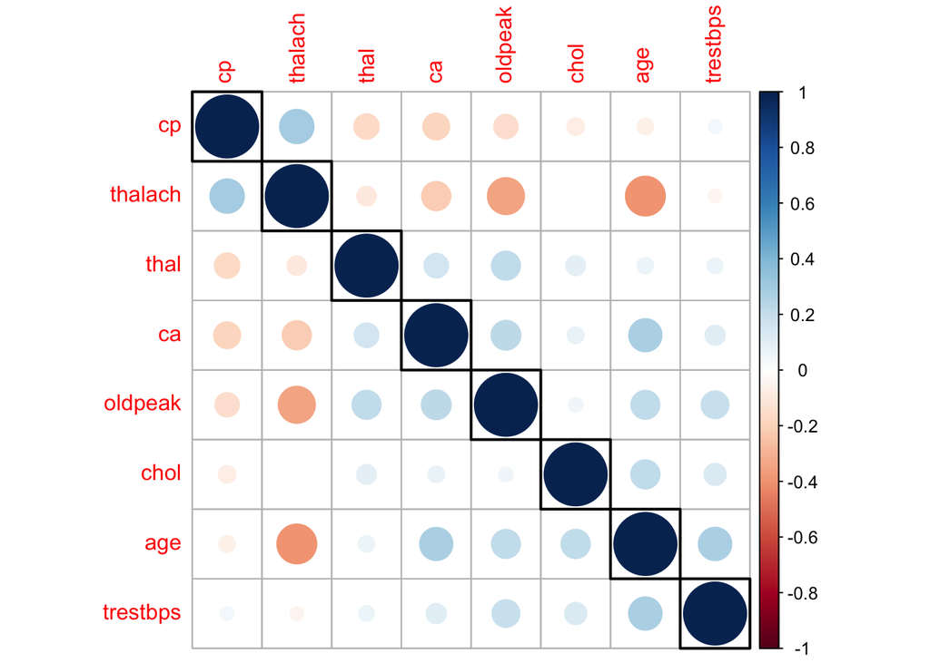

```r
corr_mat <- cor(cardio[,7:ncol(cardio)])

corrplot(corr_mat, order = "hclust", tl.cex = 1, addrect = 8)
```

As we can see here, there is good correlation between some variables.

Lets try another plotting type for our numeric variables to see outliers

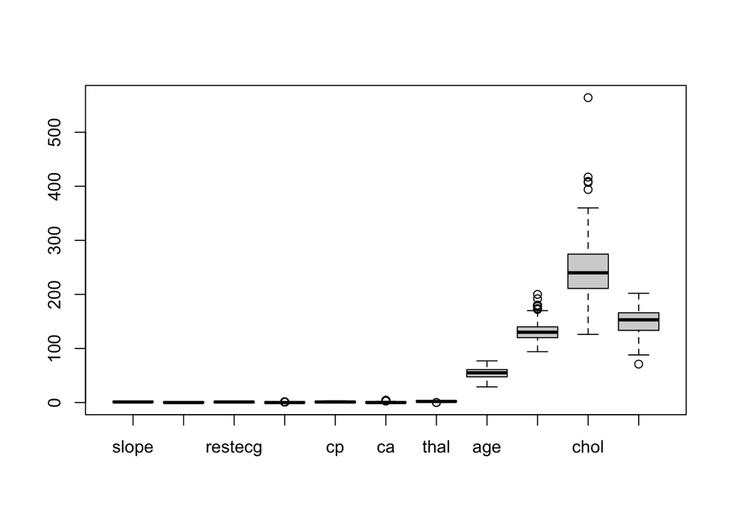

```r
boxplot(cardio[,3:13])
```

And now, we can visualize the prediction ratio.

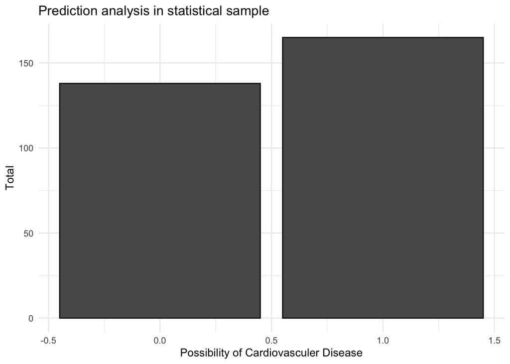

```r
ggplot(cardio, aes(x = target, fill = target)) +
  geom_bar(position = 'dodge', color = 'black') +
  ggtitle('Prediction analysis in statistical sample') +
  xlab('Possibility of Cardiovasculer Disease') +
  ylab('Total') +
  theme_minimal() +
  theme(legend.position = 'right') +
  guides(fill = guide_legend(nrow = 2,byrow = TRUE)) +
  scale_fill_discrete(name = " Cardiovasculer Diseases", labels = c("No", "Yes"))
```

See the above analysis in another point of view:

[figure not shown]

```r
ggplot(cardio, aes(x=cardio$target, fill=cardio$sex)) +
  geom_bar() +
  xlab("Cardiovasculer Disease") +
  ylab("Count") +
  ggtitle("Analysis of possibility of cardiovasculer disease") +
  scale_fill_discrete(name = "Heart Disease", labels = c("No", "Yes"))
```

Disturbution of female and male sex analysis.

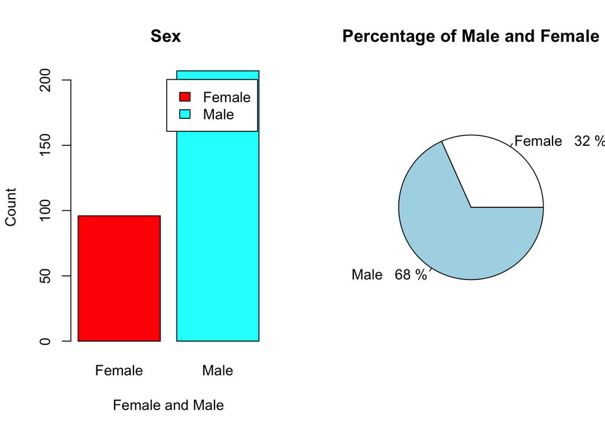

```r
x=table(cardio$sex)
par(mfrow=c(1,2))
barplot(x,
        col=rainbow(2),
        legend=rownames(x),
        xlab="Female and Male",
        ylab="Count",
        main="Sex ")

pct=round(x/sum(x)*100)
lbs=paste(c("Female","Male")," ",pct,"%",sep=" ")
pie(x,labels=lbs,main="Percentage of Male and Female")
```

```r
range(cardio$age)
```

```
## [1] 29 77
```

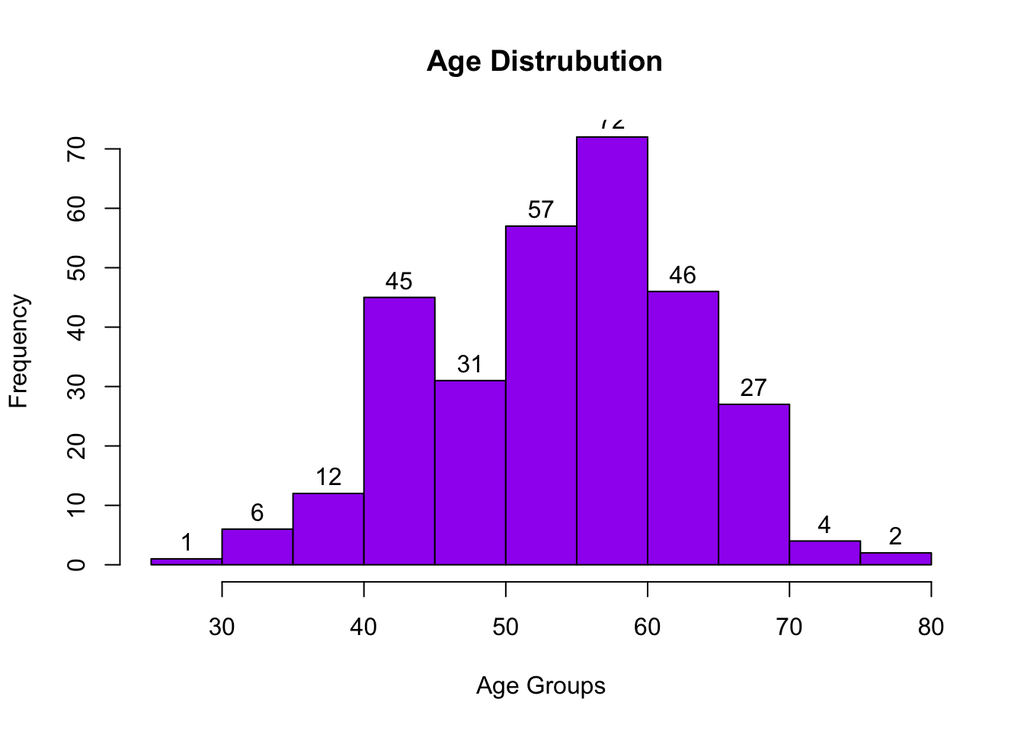

```r
hist(cardio$age,labels=TRUE,main=" Age Distrubution",xlab="Age Groups",ylab="Frequency",col="purple")
```

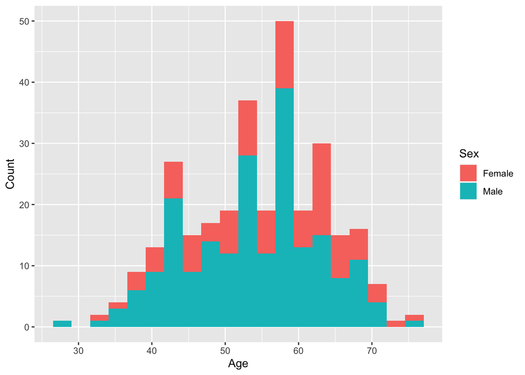

```r
cardio %>%
  ggplot(aes(x=age,fill=sex)) +
  geom_histogram(bins = 20) +
  xlab("Age") +
  ylab("Count")+
  guides(fill = guide_legend(title = "Sex"))
```

Lets see more deeper analysis in some feature related to cardiovasuler diseases

```r
p1 <- cardio %>%
  ggplot(aes(x=age,y=chol,color=sex, size=chol))+
  geom_point(alpha=0.5)+xlab("Age") +
  ylab("Cholesterol")+
  ggtitle('Cholesterol in mg/dl in sex distribution') +
  guides(fill = guide_legend(title = "Sex"))

p2 <-cardio %>%
  ggplot(aes(x=age,y=thalach,color=sex, size=thalach))+
  geom_point(alpha=0.5)+xlab("Age") +
  xlab("Age") +
  ylab("Max. Heart Rate in sex distribution")+
  guides(fill = guide_legend(title = "Sex"))



p3 <-cardio %>%
  ggplot(aes(x=age,y=cp,color=sex, size=cp))+
  geom_point(alpha=0.5)+xlab("Age") +
  xlab("Age") +
  ylab("Chest Pain in sex distribution")+
  guides(fill = guide_legend(title = "Sex"))


p4 <-cardio %>%
  ggplot(aes(x=age,y=exang,color=sex, size=exang))+
  geom_point(alpha=0.5)+xlab("Age") +
  xlab("Age") +
  ylab("exercise induced angina in sex distribution")+
  guides(fill = guide_legend(title = "Sex"))
```

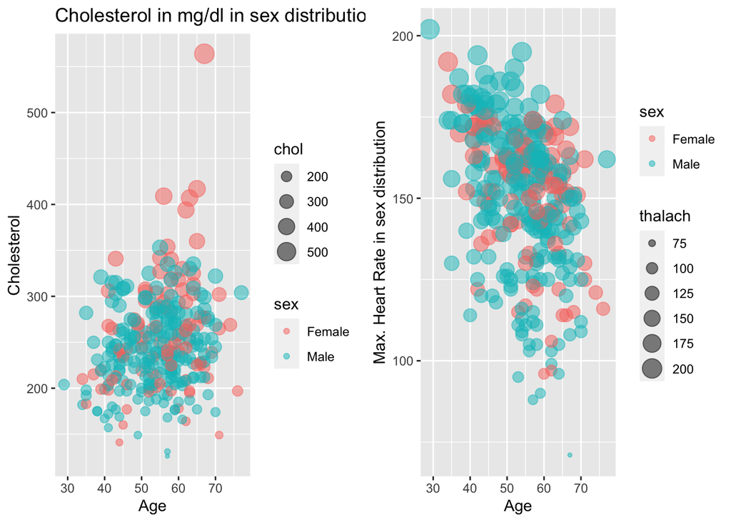

```r
grid.arrange(p1,p2, ncol=2)
```

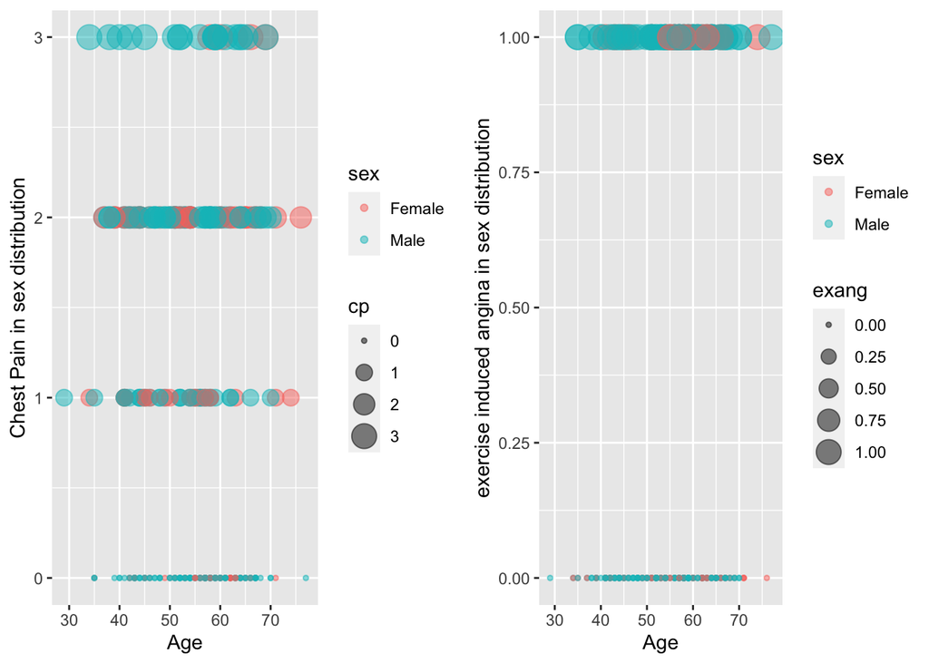

```r
grid.arrange(p3,p4,ncol=2)
```

#PCA - PRINCIPLE COMPONENT ANALYSIS

While our dependent variable is Target which has 2 values : 0 and 1. * 0 means there is no heart attack * 1 means there is Heart Attack.

We are going to use this variable for our PCA analysis

```r
set.seed(1234)
data_i <- createDataPartition(cardio$target, p=0.7, list = FALSE)
traindata <- cardio[data_i, -1]
testdata <- cardio[-data_i, -1]
```

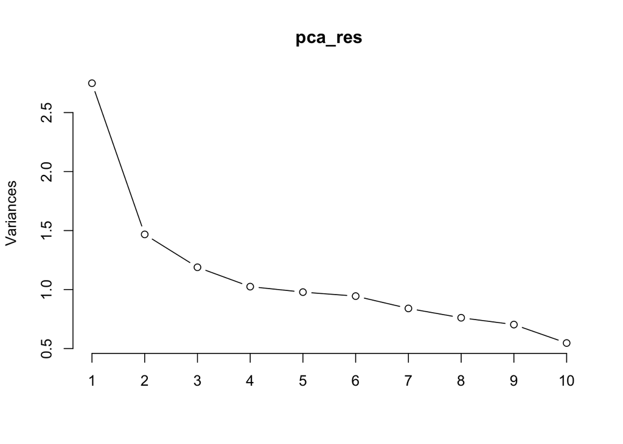

```r
pca_res <- prcomp(cardio[,3:ncol(cardio)], center = TRUE, scale = TRUE)
plot(pca_res, type="l")
```

Lets see the results

```r
summary(pca_res)
```

```
## Importance of components:
##                           PC1    PC2     PC3    PC4     PC5    PC6    PC7
## Standard deviation     1.6580 1.2114 1.09031 1.0123 0.98904 0.9718 0.9165
## Proportion of Variance 0.2291 0.1223 0.09906 0.0854 0.08152 0.0787 0.0700
## Cumulative Proportion  0.2291 0.3514 0.45044 0.5358 0.61736 0.6961 0.7661
##                            PC8     PC9    PC10    PC11    PC12
## Standard deviation     0.87235 0.83849 0.73941 0.65052 0.61102
## Proportion of Variance 0.06342 0.05859 0.04556 0.03527 0.03111
## Cumulative Proportion  0.82947 0.88806 0.93362 0.96889 1.00000
```

We are going to pick first two components which explains the 0.3514 of the variance. We need almost 11 components to explain around %96 of the variance.

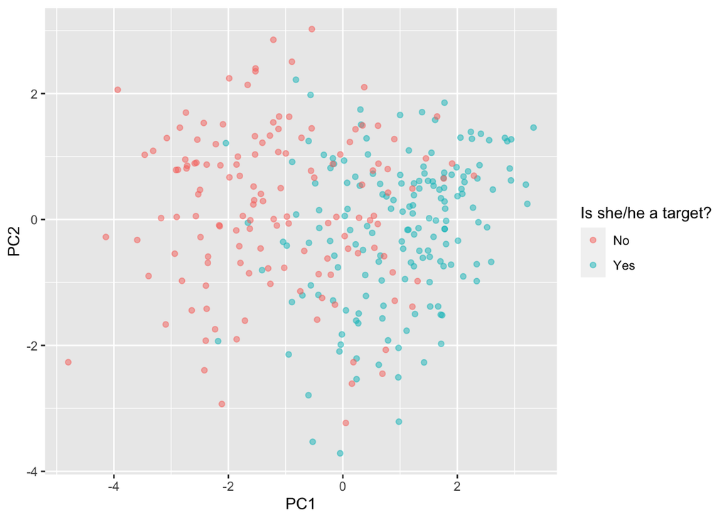

```r
pca_data <- as.data.frame(pca_res$x)

ggplot(pca_data, aes(x=PC1, y=PC2, col=cardio_2$target)) + geom_point(alpha=0.5) + labs(colour = "Is she/he a target?")
```

We can see here the density of the two components

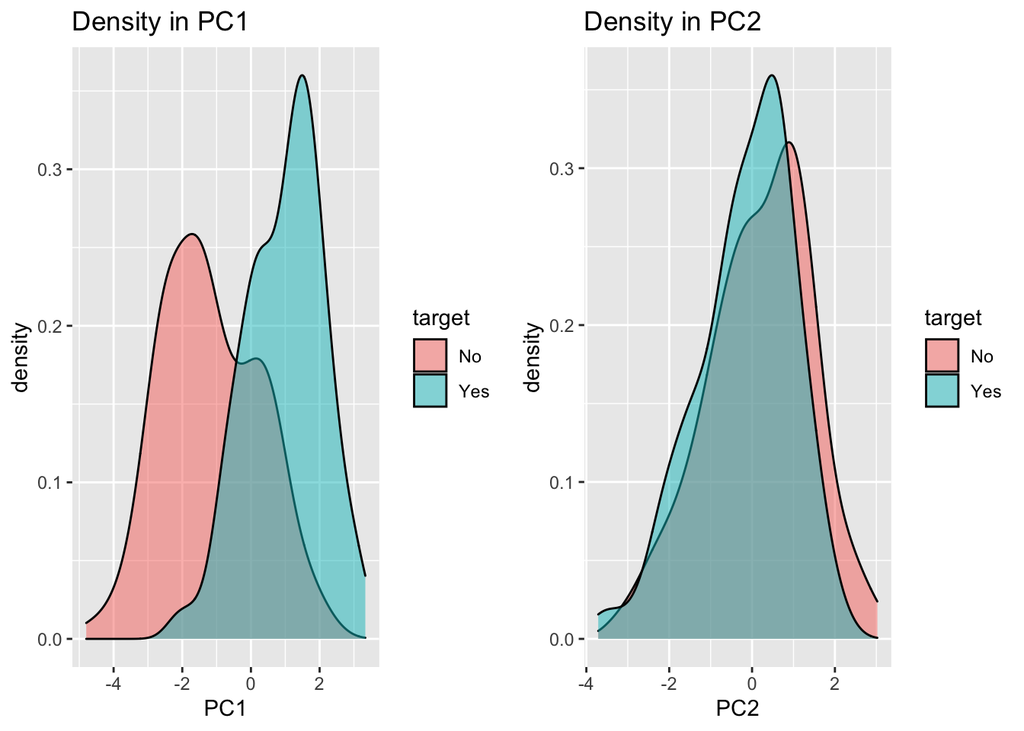

```r
target <- cardio_2$target

pc1 <- ggplot(pca_data, aes(x=PC1, fill=target)) + geom_density(alpha=0.5)  + ggtitle('Density in PC1')

pc2 <- ggplot(pca_data, aes(x=PC2, fill=target)) + geom_density(alpha=0.5)  + ggtitle('Density in PC2')

grid.arrange(pc1, pc2, ncol=2)
```

## Referances

- https://www.datacamp.com/
- Principal Component Analysis in R Youtube by Hefin Rhys
- kaggle
- https://stackoverflow.com/